# GAM en series de tiempo: Prophet

Juan Manuel Barriola y Sofia Perini

21 de Noviembre de 2020

```r
library(dplyr)
library(ggplot2)
library(prophet)
library(lubridate)
```

# Prophet

Es un procedimiento para **pronosticar datos de series de tiempo basado en un modelo aditivo** donde las tendencias no lineales se ajustan a la estacionalidad anual, semanal y diaria, más los efectos de eventos especiales. Funciona mejor con series de tiempo que tienen fuertes efectos estacionales y varias temporadas de datos históricos. Es robusto ante datos faltantes y cambios de tendencia, y normalmente maneja bien valores atípicos.

[Prophet](https://facebook.github.io/prophet/) es un software de código abierto lanzado por Facebook.

## Problema

Queremos predecir el número de visitantes de un local de ropa en un determinado momento.

## Carga de datos

El dataset consiste en información real de 8 meses de visitantes de un local de ropa localizado en un shopping de gran tamaño.

```r
shopping <- read.csv('local-shopping_prophet.csv') %>%
  rename(.,visitantes=Total.de.Visitantes) %>%
  mutate(Dia = ymd(Dia))
glimpse(shopping)
```

```
Rows: 228
Columns: 3
$ Dia        <date> 2017-09-14, 2017-09-15, 2017-09-16, 2017-09-17, 2...
$ visitantes <int> 589, 696, 1034, 940, 540, 526, 312, 553, 639, 793,...
$ Clima      <chr> "Parcialmente Nublado", "Soleado", "Soleado", "Par...
```

Se observa que la serie de tiempo presenta un comportamiento cíclico con algunos eventos atípicos:

- Aumentos debidos a promociones y Navidad
- Caídas por cierre del local o caídas del sistema de medición

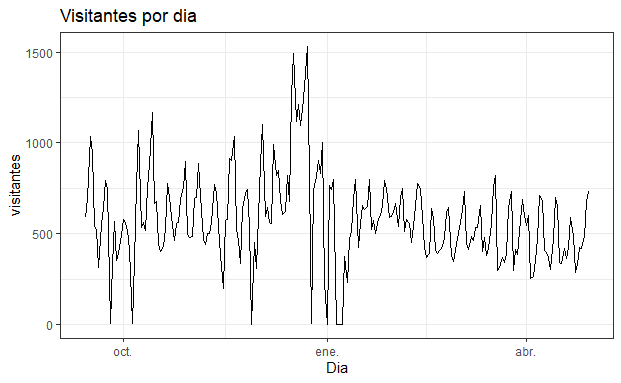

```r
ggplot(shopping, aes(Dia, visitantes)) + geom_line() + theme_bw() + labs(title='Visitantes por dia')
```

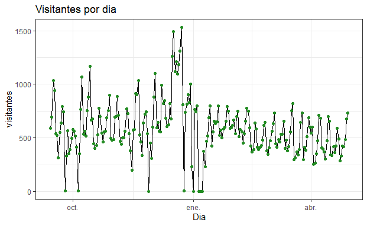

```r
 ggplot(shopping, aes(Dia, visitantes)) + geom_line() + geom_point(color='forestgreen') + theme_bw() + labs(title='Visitantes por dia')
```

# Técnicas de suavizado

Una primera aproximación puede ser tratar de utilizar técnicas de suavizado.

En este caso estamos utilizando **loess** como una herramienta gráfica con el comando `geom_smooth()` de ggplot.

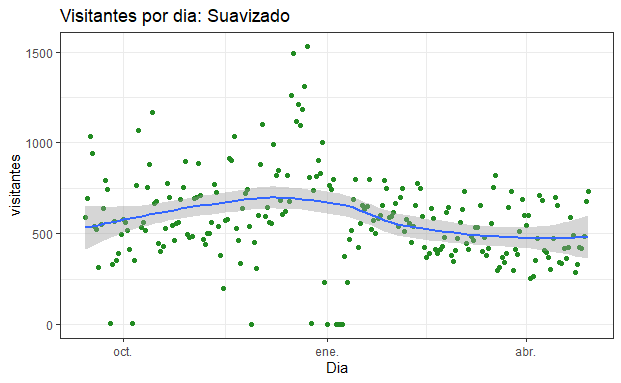

```r
ggplot(shopping, aes(Dia, visitantes)) + geom_point(color='forestgreen') + geom_smooth() + theme_bw() + labs(title='Visitantes por dia: Suavizado')
```

Si bien está suavizando, el resultado es bastante pobre ya que el modelo no está logrando representar bien la variabilidad de los datos.

## Distintas ventanas

Ahora realizamos 4 modelos de LOESS modificando la ventana (**span**) para cada uno de ellos.

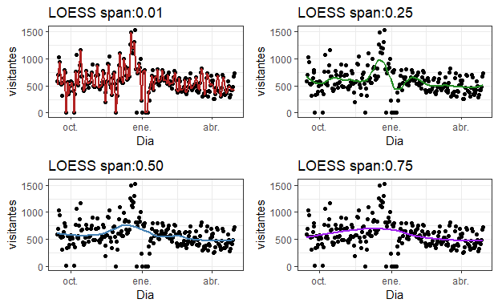

```r
loess=stats::loess(visitantes~as.numeric(Dia), data = shopping, na.action = 'na.exclude', model = T, span=0.01)
shopping['loess']=predict(loess,shopping)
loess_1 = ggplot(shopping, aes(Dia,visitantes)) + geom_point() + geom_line(aes(y=loess), color='firebrick', size=1) +
  labs(title= "LOESS span:0.01") + theme_bw()

loess=stats::loess(visitantes~as.numeric(Dia), data = shopping, na.action = 'na.exclude', model = T, span=0.25)
shopping['loess']=predict(loess,shopping)
loess_2 = ggplot(shopping, aes(Dia,visitantes)) + geom_point() + geom_line(aes(y=loess), color='forestgreen', size=1) +
  labs(title= "LOESS span:0.25") + theme_bw()

loess=stats::loess(visitantes~as.numeric(Dia), data = shopping, na.action = 'na.exclude', model = T, span=0.5)
shopping['loess']=predict(loess,shopping)
loess_3 = ggplot(shopping, aes(Dia,visitantes)) + geom_point() + geom_line(aes(y=loess), color='steelblue', size=1) +
  labs(title= "LOESS span:0.50") + theme_bw()

loess=stats::loess(visitantes~as.numeric(Dia), data = shopping, na.action = 'na.exclude', model = T, span=0.75)
shopping['loess']=predict(loess,shopping)
loess_4 = ggplot(shopping, aes(Dia,visitantes)) + geom_point() + geom_line(aes(y=loess), color='purple', size=1) +
  labs(title= "LOESS span:0.75") + theme_bw()

cowplot::plot_grid(loess_1, loess_2, loess_3,loess_4)
```

Se nota que para un **span muy pequeño** nuestro modelo va a tener un problema de **OVERFITTING**: no va a poder generalizar. Mientras que para **spans grandes** tenemos un problema de **UNDERFITTING**: nuestro modelo no logra captar bien la variabilidad del fenómeno.

# Prophet

Vamos a trabajar sobre la implementación de Prophet en R.

## Preparacion del dataset

Prophet requiere que le pasemos el dataset con:

- **ds**: la variable temporal
- **y**: la variable a predecir

```r
# Eliminamos observaciones con menos de 250 visitantes (cuestion de negocio)
shopping[shopping['visitantes']<250,'visitantes'] = NA
# Creamos el dataset
prophet_df = shopping %>% select(Dia, visitantes) %>% rename(., ds=Dia, y=visitantes)
```

## Modelo

Recordemos que el modelo subyacente es el propuesto por Harvey & Peters (1990):

$y(t)=g(t)+s(t)+h(t)+\epsilon_t$

Hay muchos parametros para tener en cuenta. Veremos algunos:

- **df**: dataframe
- **growth**: tipo de tendencia: lineal o logistica
- **yearly.seasonality**: hay estacionalidad anual?
- **yearly.seasonality**: hay estacionalidad diaria?
- **holidays**: dataframe con fechas de vacaciones/eventos especiales

### Modelo básico

La funcion `prophet` crea el modelo, podemos pasarle o no el dataframe.

La funcion `prophet.fit` aplica un modelo creado a un dataframe.

```r
# Llamamos solo al modelo
prophet_base=prophet()
# Le pasamos el dataset
prophet_base = fit.prophet(m = prophet_base, prophet_df)
```

```
Disabling yearly seasonality. Run prophet with yearly.seasonality=TRUE to override this.
Disabling daily seasonality. Run prophet with daily.seasonality=TRUE to override this.
```

Notemos que el modelo automáticamente deshabilita la estacionalidad anual y diaria.

#### Gráfico del modelo

Llamando a `plot` obtenemos el valor predicho del modelo y el valor original.

Es difícil de notar pero el modelo realiza predicciones aun para los dias en los cuales no hay datos.

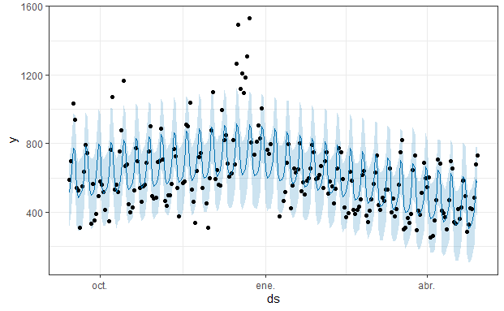

```r
plot(prophet_base,fcst=predict(prophet_base, prophet_df)) +theme_bw()
```

#### Componentes del modelo

La funcion `prophet_plot_components` nos devuelve los efectos de los componentes en nuestra variable a predecir.

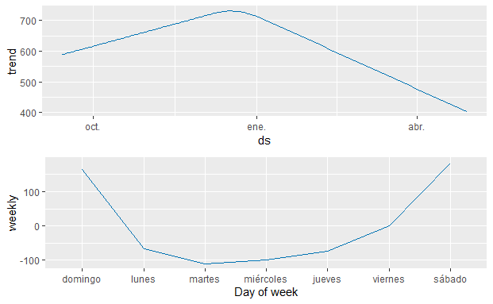

```r
prophet_plot_components(prophet_base, fcst=predict(prophet_base, prophet_df)) +theme_bw()
```

En este caso tenemos la tendencia de los visitantes y la estacionalidad semanal. Esta última parece tener bastante sentido ya que nos muestra que hay mayor cantidad de visitantes durante el fin de semana.

#### Diagnóstico del modelo

La funcion `cross_validation` permite realizar pronósticos realizando un esquema de cross-validation temporal y, a partir de ellos, obtener ciertas métricas de performance.

- **horizon**: horizonte del pronostico. Cuánto tiempo deseo predecir
- **period**: periodo entre fechas de analisis. Cuánto voy corriendo mi ventana
- **initial**: período inicial de entrenamiento

```r
cv_base = cross_validation(prophet_base, initial = 45, period = 7, horizon = 15, units = 'days')
```

```
Making 24 forecasts with cutoffs between 2017-11-04 and 2018-04-14
```

```r
cv_base
```

| y | ds | yhat | yhat_lower | yhat_upper | cutoff |
| --- | --- | --- | --- | --- | --- |
| 710 | 2017-11-05 | 827.5072 | 645.02598 | 987.9613 | 2017-11-04 |
| 468 | 2017-11-06 | 583.8158 | 429.40198 | 755.7868 | 2017-11-04 |
| 439 | 2017-11-07 | 503.0724 | 335.24673 | 677.6483 | 2017-11-04 |
| 502 | 2017-11-08 | 491.3577 | 317.33134 | 664.5229 | 2017-11-04 |
| 500 | 2017-11-09 | 592.5476 | 413.84692 | 754.1202 | 2017-11-04 |
| 564 | 2017-11-10 | 639.8363 | 475.19897 | 810.9102 | 2017-11-04 |
| 771 | 2017-11-11 | 864.2158 | 708.07054 | 1048.7431 | 2017-11-04 |
| 727 | 2017-11-12 | 834.2786 | 659.58523 | 1000.3804 | 2017-11-04 |
| 540 | 2017-11-13 | 590.5872 | 411.36065 | 755.7476 | 2017-11-04 |
| 378 | 2017-11-14 | 509.8438 | 340.13112 | 679.9847 | 2017-11-04 |

[output cut: 328 more lines]

La funcion `performance_metrics` computa varias métricas de performance a partir de un dataframe de cross validation de prophet.

```r
performance_metrics(cv_base, rolling_window = 0.5)
```

| horizon | mse | rmse | mae | mape | coverage |
| --- | --- | --- | --- | --- | --- |
| 8 days | 42434.43 | 205.9962 | 145.3953 | 0.2294063 | 0.7958580 |
| 9 days | 43008.15 | 207.3841 | 145.8626 | 0.2366517 | 0.7895182 |
| 10 days | 44052.36 | 209.8865 | 147.9486 | 0.2412270 | 0.7784924 |
| 11 days | 44523.72 | 211.0065 | 150.6332 | 0.2438130 | 0.7721893 |
| 12 days | 47917.58 | 218.9008 | 159.1380 | 0.2594936 | 0.7320020 |
| 13 days | 50052.91 | 223.7251 | 163.3448 | 0.2638779 | 0.7198353 |
| 14 days | 52619.89 | 229.3902 | 167.4751 | 0.2665215 | 0.7170054 |
| 15 days | 55110.94 | 234.7572 | 170.1950 | 0.2714019 | 0.7130178 |

### Modelo con estacionalidad mensual

La funcion `add_seasonality` nos permite agregar nuevas estacionalidades. Las estacionalidades se modelan utilizando series de Fourier que nosotros debemos definir.

Definimos:

- **m**: modelo
- **name**: nombre de la estacionalidad
- **period**: cantidad de dias del periodo
- **fourier.order**: orden de la serie de fourier para modelar la estacionalidad

```r
# Llamamos solo al modelo
prophet_mensual=prophet()
# Agregamos la estacionalidad mensual
prophet_mensual=add_seasonality(prophet_mensual, name='monthly', period=365/12, fourier.order = 4)
# Le pasamos el dataset
prophet_mensual = fit.prophet(m = prophet_mensual, prophet_df)
```

```
Disabling yearly seasonality. Run prophet with yearly.seasonality=TRUE to override this.
Disabling daily seasonality. Run prophet with daily.seasonality=TRUE to override this.
```

Notemos que sigue deshabilitando la estacionalidad anual y diaria.

#### Grafico del modelo

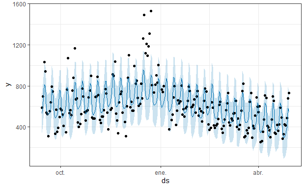

```r
plot(prophet_mensual,fcst=predict(prophet_mensual, prophet_df)) +theme_bw()
```

#### Componentes del modelo

La funcion `prophet_plot_components` nos devuelve los efectos de los componentes en nuestra variable a predecir

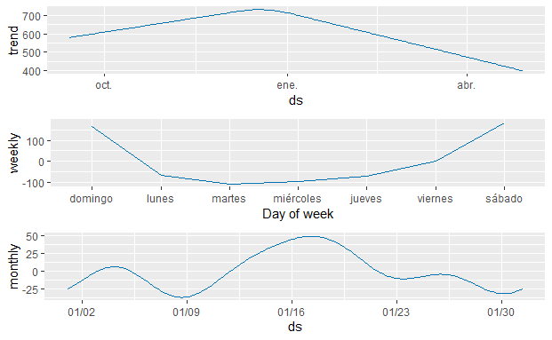

```r
prophet_plot_components(prophet_mensual, fcst=predict(prophet_mensual, prophet_df)) +theme_bw()
```

Notemos que la tendencia y estacionalidad semanal se mantiene y ahora se agrega la tendencia mensual que habíamos incorporado. Nos indica que el ciclo mensual se caracteriza por un crecimiento en la mitad de mes.

#### Diagnostico del modelo

| y | ds | yhat | yhat_lower | yhat_upper | cutoff |
| --- | --- | --- | --- | --- | --- |
| 710 | 2017-11-05 | 822.1001 | 686.46590 | 961.3930 | 2017-11-04 |
| 468 | 2017-11-06 | 543.0680 | 407.22576 | 690.1933 | 2017-11-04 |
| 439 | 2017-11-07 | 454.5758 | 319.04555 | 599.5547 | 2017-11-04 |
| 502 | 2017-11-08 | 496.4709 | 352.04759 | 634.6523 | 2017-11-04 |
| 500 | 2017-11-09 | 671.5231 | 528.80905 | 812.0864 | 2017-11-04 |
| 564 | 2017-11-10 | 820.6870 | 675.15708 | 955.1105 | 2017-11-04 |
| 771 | 2017-11-11 | 1101.9276 | 964.21951 | 1243.8040 | 2017-11-04 |
| 727 | 2017-11-12 | 1072.3849 | 942.59419 | 1207.5406 | 2017-11-04 |
| 540 | 2017-11-13 | 786.2759 | 647.20709 | 923.8810 | 2017-11-04 |
| 378 | 2017-11-14 | 640.9658 | 510.31317 | 776.6579 | 2017-11-04 |

[output cut: 328 more lines]

La funcion `performance_metrics` computa varias metricas de performance a partir de un dataframe de cross validation de prophet

```r
performance_metrics(cv_mensual, rolling_window = 0.5)
```

| horizon | mse | rmse | mae | mape | coverage |
| --- | --- | --- | --- | --- | --- |
| 8 days | 50201.53 | 224.0570 | 158.7548 | 0.2560851 | 0.7159763 |
| 9 days | 51628.42 | 227.2189 | 161.0306 | 0.2674497 | 0.7151310 |
| 10 days | 52447.69 | 229.0146 | 162.6727 | 0.2719211 | 0.7108310 |
| 11 days | 52873.02 | 229.9413 | 165.0368 | 0.2733705 | 0.7159763 |
| 12 days | 56663.44 | 238.0408 | 172.8856 | 0.2869968 | 0.7029093 |
| 13 days | 59818.48 | 244.5782 | 178.2295 | 0.2929623 | 0.6992539 |
| 14 days | 62276.93 | 249.5535 | 181.2026 | 0.2926357 | 0.6905068 |
| 15 days | 64356.78 | 253.6864 | 183.1389 | 0.2968551 | 0.6863905 |

### Modelo completo

Como último paso vamos a agregar las ventas de navidad y ciertos dias de promociones como eventos especiales

#### Dataframe de eventos

Creamos el dataframe de eventos con: nombre del evento, fechas y una “ventana” para definir si el evento se estira a ciertos dias.

```r
# Navidad
christmas = data.frame(holiday= 'christmas',
  ds=ymd(c('2017-12-16','2017-12-17','2017-12-18',
                        '2017-12-19','2017-12-20','2017-12-21',
                        '2017-12-22','2017-12-23')),
  lower_window= 0,
  upper_window= 0)

# Promociones
big_sales = data.frame(
  holiday= 'big_sales',
  ds= ymd(c('2017-09-16','2017-10-08','2017-10-14',
                        '2017-11-20','2017-12-03','2017-12-30')),
  lower_window= 0,
  upper_window= 0)

holidays= bind_rows(christmas, big_sales)
glimpse(holidays)
```

```
Rows: 14
Columns: 4
$ holiday      <chr> "christmas", "christmas", "christmas", "christma...
$ ds           <date> 2017-12-16, 2017-12-17, 2017-12-18, 2017-12-19,...
$ lower_window <dbl> 0, 0, 0, 0, 0, 0, 0, 0, 0, 0, 0, 0, 0, 0
$ upper_window <dbl> 0, 0, 0, 0, 0, 0, 0, 0, 0, 0, 0, 0, 0, 0
```

```r
# Llamamos al modelo con el dataset de eventos
prophet_full=prophet(holidays = holidays)
# Agregamos la estacionalidad mensual
prophet_full=add_seasonality(prophet_full, name='monthly', period=30.5, fourier.order = 4)
# Le pasamos el dataset
prophet_full = fit.prophet(m = prophet_full, prophet_df)
```

```
Disabling yearly seasonality. Run prophet with yearly.seasonality=TRUE to override this.
Disabling daily seasonality. Run prophet with daily.seasonality=TRUE to override this.
```

Fijense que el modelo automaticamente deshabilita la estacionalidad anual y diaria.

#### Grafico del modelo

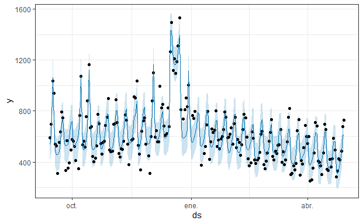

```r
plot(prophet_full,fcst=predict(prophet_full, prophet_df)) +theme_bw()
```

#### Componentes del modelo

La funcion `prophet_plot_components` nos devuelve los efectos de los componentes en nuestra variable a predecir

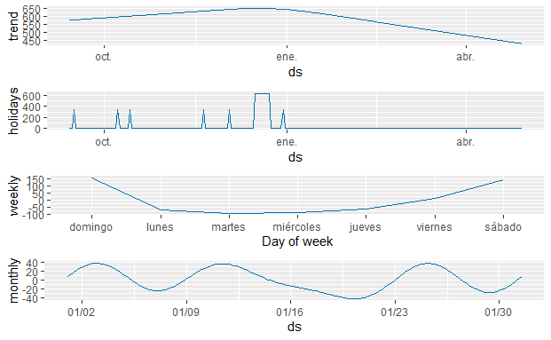

```r
prophet_plot_components(prophet_full, fcst=predict(prophet_full, prophet_df)) +theme_bw()
```

La tendencia y estacionalidad semanal se mantienen aproximadamente igual. La estacionalidad mensual cambia bastante y se observa que existen tres picos en el ciclo mensual. Por su parte, los eventos se modelan como pequeños saltos o picos.

#### Diagnostico del modelo

| y | ds | yhat | yhat_lower | yhat_upper | cutoff |
| --- | --- | --- | --- | --- | --- |
| 710 | 2017-11-05 | 789.0090 | 678.9597 | 898.8819 | 2017-11-04 |
| 468 | 2017-11-06 | 529.3885 | 414.7894 | 635.5235 | 2017-11-04 |
| 439 | 2017-11-07 | 408.8110 | 299.6231 | 523.1824 | 2017-11-04 |
| 502 | 2017-11-08 | 433.6865 | 328.1435 | 550.6927 | 2017-11-04 |
| 500 | 2017-11-09 | 618.6020 | 499.8338 | 733.5267 | 2017-11-04 |
| 564 | 2017-11-10 | 788.1399 | 680.8926 | 896.5998 | 2017-11-04 |
| 771 | 2017-11-11 | 1015.1674 | 900.3873 | 1125.5719 | 2017-11-04 |
| 727 | 2017-11-12 | 1030.4000 | 916.5883 | 1142.4327 | 2017-11-04 |
| 540 | 2017-11-13 | 781.0116 | 674.7774 | 890.4560 | 2017-11-04 |
| 378 | 2017-11-14 | 610.2952 | 501.4348 | 728.0644 | 2017-11-04 |

[output cut: 328 more lines]

```r
performance_metrics(cv_full, rolling_window = 0.5)
```

| horizon | mse | rmse | mae | mape | coverage |
| --- | --- | --- | --- | --- | --- |
| 8 days | 23310.11 | 152.6765 | 114.5693 | 0.1948654 | 0.6863905 |
| 9 days | 25197.80 | 158.7381 | 118.5794 | 0.2059345 | 0.6855452 |
| 10 days | 27638.24 | 166.2475 | 121.7604 | 0.2095625 | 0.6815024 |
| 11 days | 29087.51 | 170.5506 | 123.7918 | 0.2098719 | 0.6834320 |
| 12 days | 32457.06 | 180.1584 | 130.8671 | 0.2210684 | 0.6587771 |
| 13 days | 35345.79 | 188.0048 | 134.5109 | 0.2216480 | 0.6400823 |
| 14 days | 37912.33 | 194.7109 | 137.8876 | 0.2213649 | 0.6372524 |
| 15 days | 39066.54 | 197.6526 | 137.7876 | 0.2221240 | 0.6331361 |

## Graficos interactivos

Prophet también nos permite realizar gráficos interactivos que suelen ser muy útiles para presentar los resultados.

```r
dyplot.prophet(prophet_full, fcst=predict(prophet_full, prophet_df))
```

```
`select_()` is deprecated as of dplyr 0.7.0.
Please use `select()` instead.
  method           from
  print.htmlwidget tools:rstudio
```

[interactive chart not shown]